# Module 80

#### Contrast SVE:

Signed variance explained (SVE) provides an indication of how similar a set of fold changes are to a gene module’s weight vector. An SVE value of 0.3, for example, indicates that 30% of the variance explained by the entire module set is accounted for by the module in question. Shown here are the SVE values for this module across a compendium of fold changes (contrasts). Extreme SVE values (e.g., > 0.05) indicate that those contrasts specifically induce (orange dots) or specifically repress (blue dots) this module. Examining the experimental conditions being compared in such contrasts (see tables below the figure) may provide insight into the gene module’s function.

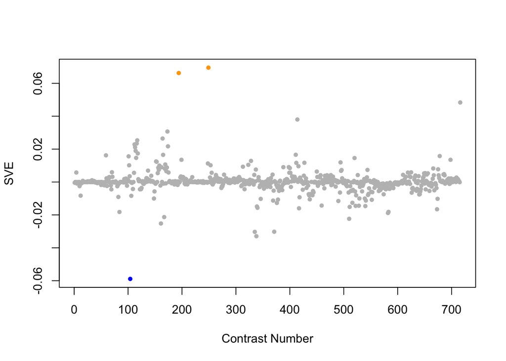

Positive SVE Contrasts:

|  | Contrast.Num | SVE | GEO.GSE | Cond.1 | Cond.2 | Mutation |
| --- | --- | --- | --- | --- | --- | --- |
| GSE42192.s2t2.vs.s0t2 | 249 | 0.07 | GSE42192 | C.elegans fed with CNCM I-4317 10 days rep1 | C.elegans fed with E.coli OP50 10 days rep1 |  |
| GSE44318.s1t1.vs.s0t1 | 194 | 0.07 | GSE44318 | 13L peptide [SL12] | NGM [SL1] |  |
| GSE10787B.s1t1.vs.s0t1 | 716 | 0.05 | GSE10787 | Microwave (de_Pomerai_10_E5_C.Elegans) | Sham (de_Pomerai_1_S1_C.Elegans) |  |
| GSE29951.s1t1.vs.s0t1 | 414 | 0.04 | GSE29951 | C.elegans MT KO mtl-1,mtl-2(zs1), raised in the absence of Cd, rep1 | C.elegans wild type raised in the absence of Cd, rep1 | mtl-1;mtl-2 |
| GSE47778.s1t3.vs.s4t3 | 173 | 0.03 | GSE47778 | N2; UV; replicate 1 | daf-2;daf-16; UV; replicate 1 | daf-2;daf-16 |

Negative SVE Contrasts:

|  | Contrast.Num | SVE | GEO.GSE | Cond.1 | Cond.2 | Mutation |
| --- | --- | --- | --- | --- | --- | --- |
| GSE57664.s1t1.vs.s0t1 | 104 | -0.06 | GSE57664 | TYR treated rep1 | control rep1 |  |
| GSE38997.s2t1.vs.s1t1 | 338 | -0.03 | GSE38997 | experiment 4 EtBr-exposed samples at 3 h 4e3 | experiment 4 control samples at 3 h 4c3 |  |
| GSE38997.s3t2.vs.s2t2 | 335 | -0.03 | GSE38997 | experiment 4 UVC- and EtBr-exposed samples at 24 h 4eu24 | experiment 4 EtBr-exposed samples at 24 h 4e24 |  |
| GSE35360C.s1t1.vs.s0t1 | 371 | -0.03 | GSE35360 | HFHQ 3d_0.2_rep1 | HFHQ 3d control_rep1 |  |
| GSE47778.s4t2.vs.s3t2 | 161 | -0.03 | GSE47778 | daf-2;daf-16; starvation; replicate 1 | daf-16; starvation; replicate 1 | daf-2;daf-16 vs. daf-16 |

$~$

#### Contrast SVE, Up-Regulated Genes Only:

Calculating SVE for up-regulated and down-regulated genes separately may be more informative in many cases than projecting the up- and down- gene sets together. This is due to the fact that the weight distribution of many modules is highly skewed, indicating that only one of the hemi-modules may be biologically meaningful (i.e., a set of genes are strongly correlated by only a few genes (or none) are strongly anti-correlated to that set.)

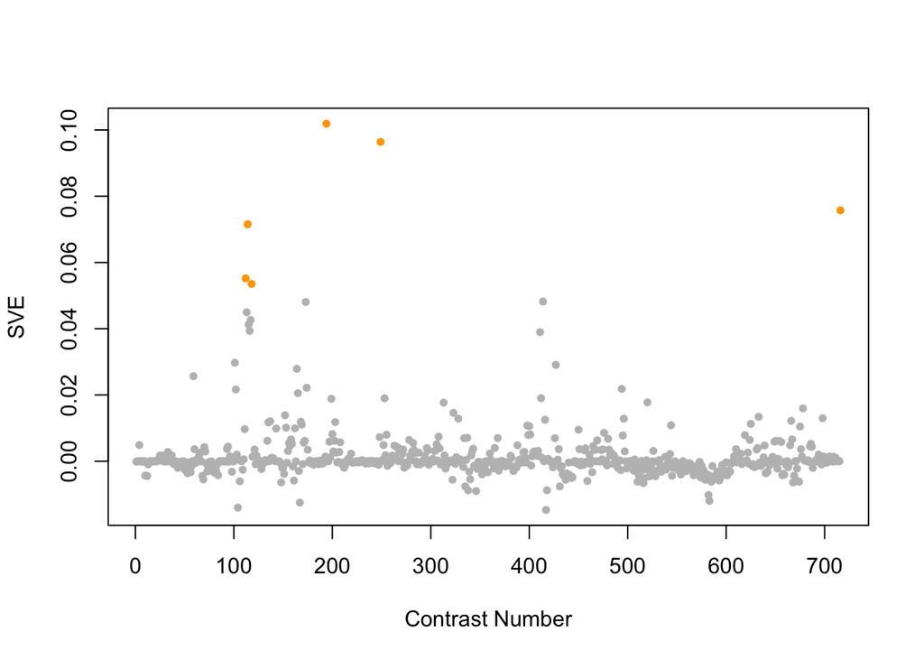

Positive SVE Contrasts:

|  | Contrast.Num | SVE | GEO.GSE | Cond.1 | Cond.2 | Mutation |
| --- | --- | --- | --- | --- | --- | --- |
| GSE44318.s1t1.vs.s0t1 | 194 | 0.10 | GSE44318 | 13L peptide [SL12] | NGM [SL1] |  |
| GSE42192.s2t2.vs.s0t2 | 249 | 0.10 | GSE42192 | C.elegans fed with CNCM I-4317 10 days rep1 | C.elegans fed with E.coli OP50 10 days rep1 |  |
| GSE10787B.s1t1.vs.s0t1 | 716 | 0.08 | GSE10787 | Microwave (de_Pomerai_10_E5_C.Elegans) | Sham (de_Pomerai_1_S1_C.Elegans) |  |
| GSE54024.s2t1.vs.s5t1 | 114 | 0.07 | GSE54024 | Wild type young adults treated with 0.1mM paraquat, biological rep 1 | ced-4(n1162) young adults, biological rep 1 |  |
| GSE54024.s4t1.vs.s5t1 | 112 | 0.06 | GSE54024 | isp-1(qm150) young adults, biological rep 1 | ced-4(n1162) young adults, biological rep 1 |  |
| GSE54024.s2t1.vs.s6t1 | 118 | 0.05 | GSE54024 | Wild type young adults treated with 0.1mM paraquat, biological rep 1 | isp-1(qm150) ced-4(n1162) double mutant young adults, biological rep 1 |  |

Negative SVE Contrasts:

|  | Contrast.Num | SVE | GEO.GSE | Cond.1 | Cond.2 | Mutation |
| --- | --- | --- | --- | --- | --- | --- |
| GSE28856.s0t2.vs.s0t1 | 417 | -0.01 | GSE28856 | Wild-type 1 h after shifting temperature rep1 | Wild-type 0 h after shifting temperature rep1 |  |
| GSE57664.s1t1.vs.s0t1 | 104 | -0.01 | GSE57664 | TYR treated rep1 | control rep1 |  |
| GSE47778.s4t3.vs.s3t3 | 167 | -0.01 | GSE47778 | daf-2;daf-16; UV; replicate 1 | daf-16; UV; replicate 1 | daf-2;daf-16 vs. daf-16 |
| GSE2180.s2t3.vs.s2t1 | 583 | -0.01 | GSE2180 | ms41-1 | ms0-1 |  |
| GSE2180.s2t2.vs.s2t1 | 582 | -0.01 | GSE2180 | ms23-1 | ms0-1 |  |

$~$

#### Contrast SVE, Down-Regulated Genes Only:

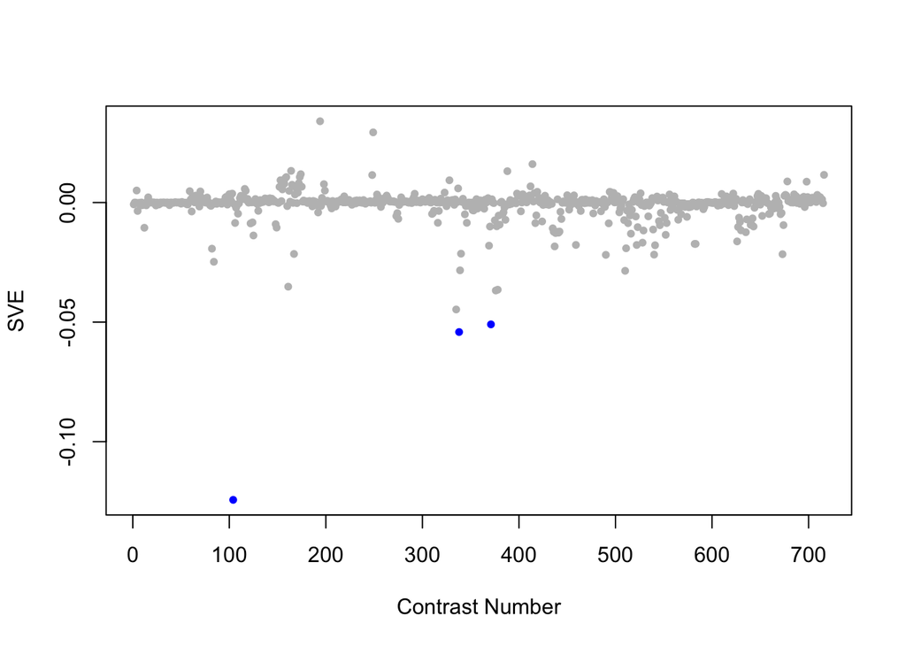

Positive SVE Contrasts:

|  | Contrast.Num | SVE | GEO.GSE | Cond.1 | Cond.2 | Mutation |
| --- | --- | --- | --- | --- | --- | --- |
| GSE44318.s1t1.vs.s0t1 | 194 | 0.03 | GSE44318 | 13L peptide [SL12] | NGM [SL1] |  |
| GSE42192.s2t2.vs.s0t2 | 249 | 0.03 | GSE42192 | C.elegans fed with CNCM I-4317 10 days rep1 | C.elegans fed with E.coli OP50 10 days rep1 |  |
| GSE29951.s1t1.vs.s0t1 | 414 | 0.02 | GSE29951 | C.elegans MT KO mtl-1,mtl-2(zs1), raised in the absence of Cd, rep1 | C.elegans wild type raised in the absence of Cd, rep1 | mtl-1;mtl-2 |
| GSE47778.s1t2.vs.s2t2 | 164 | 0.01 | GSE47778 | N2; starvation; replicate 1 | daf-2; starvation; replicate 1 | daf-2 |
| GSE32949.s1t1.vs.s0t1 | 388 | 0.01 | GSE32949 | C. elegans exposed to space condition, technical rep1 | C. elegans ground control, technical rep1 |  |

Negative SVE Contrasts:

|  | Contrast.Num | SVE | GEO.GSE | Cond.1 | Cond.2 | Mutation |
| --- | --- | --- | --- | --- | --- | --- |
| GSE57664.s1t1.vs.s0t1 | 104 | -0.12 | GSE57664 | TYR treated rep1 | control rep1 |  |
| GSE38997.s2t1.vs.s1t1 | 338 | -0.05 | GSE38997 | experiment 4 EtBr-exposed samples at 3 h 4e3 | experiment 4 control samples at 3 h 4c3 |  |
| GSE35360C.s1t1.vs.s0t1 | 371 | -0.05 | GSE35360 | HFHQ 3d_0.2_rep1 | HFHQ 3d control_rep1 |  |
| GSE38997.s3t2.vs.s2t2 | 335 | -0.04 | GSE38997 | experiment 4 UVC- and EtBr-exposed samples at 24 h 4eu24 | experiment 4 EtBr-exposed samples at 24 h 4e24 |  |
| GSE35354B.s1t2.vs.s1t1 | 376 | -0.04 | GSE35354 | TA100_rep1 | TA Control_rep1 |  |

$~$

$~$

#### GO Term Enrichment:

This analysis tests each hemi-module for enrichment of specific GO terms. Only gene-level annotations (e.g., as would be found on the gene’s page in Wormbase) are tested - the hierarchical structure of the GO ontology is not taken into account.

*Note: At least the top two most enriched terms from each GO domain (BP/MF/CC) are shown, even when not statistically significant.*

##### Enriched GO terms: Hemi-module A

| ID | GO.Term | GO Domain | Raw p-value | Adj p-value |
| --- | --- | --- | --- | --- |
| [GO_0006370](http://amigo.geneontology.org/amigo/term/GO:0006370) | 7-methylguanosine mRNA capping | BP | 6.41e-05 | 2.33e-01 |
| [GO_0019216](http://amigo.geneontology.org/amigo/term/GO:0019216) | regulation of lipid metabolic process | BP | 1.54e-04 | 2.81e-01 |
| [GO_0005515](http://amigo.geneontology.org/amigo/term/GO:0005515) | protein binding | MF | 1.62e-05 | 3.31e-02 |
| [GO_0046872](http://amigo.geneontology.org/amigo/term/GO:0046872) | metal ion binding | MF | 6.41e-04 | 5.41e-01 |
| [GO_0005634](http://amigo.geneontology.org/amigo/term/GO:0005634) | nucleus | CC | 4.84e-09 | 4.50e-06 |
| [GO_0016021](http://amigo.geneontology.org/amigo/term/GO:0016021) | integral component of membrane | CC | 4.31e-08 | 2.00e-05 |
| [GO_0016020](http://amigo.geneontology.org/amigo/term/GO:0016020) | membrane | CC | 5.73e-07 | 1.77e-04 |
| [GO_0005737](http://amigo.geneontology.org/amigo/term/GO:0005737) | cytoplasm | CC | 6.43e-06 | 1.49e-03 |
| [GO_0070822](http://amigo.geneontology.org/amigo/term/GO:0070822) | Sin3-type complex | CC | 4.59e-04 | 8.53e-02 |

##### Enriched GO terms: Hemi-module B

| ID | GO.Term | GO Domain | Raw p-value | Adj p-value |
| --- | --- | --- | --- | --- |
| [GO_0006874](http://amigo.geneontology.org/amigo/term/GO:0006874) | cellular calcium ion homeostasis | BP | 9.09e-04 | 9.69e-01 |
| [GO_0046854](http://amigo.geneontology.org/amigo/term/GO:0046854) | phosphatidylinositol phosphorylation | BP | 9.09e-04 | 9.69e-01 |
| [GO_0008934](http://amigo.geneontology.org/amigo/term/GO:0008934) | inositol monophosphate 1-phosphatase activity | MF | 2.66e-03 | 6.79e-01 |
| [GO_0015367](http://amigo.geneontology.org/amigo/term/GO:0015367) | oxoglutarate:malate antiporter activity | MF | 2.66e-03 | 6.79e-01 |
| [GO_0005739](http://amigo.geneontology.org/amigo/term/GO:0005739) | mitochondrion | CC | 2.65e-05 | 2.46e-02 |
| [GO_0000139](http://amigo.geneontology.org/amigo/term/GO:0000139) | Golgi membrane | CC | 4.17e-03 | 1.00e+00 |

$~$

$~$

#### Tissue Enrichment:

This analysis tests each hemi-module for enrichment of genes associated with anatomy terms. Negative enrichment scores indicate fewer hemi-module genes than expected by random chance were associated with the anatomy term in question.

##### Enriched tissues: Hemi-module A

No significant annotations.

##### Enriched tissues: Hemi-module B

No significant annotations.

$~$

$~$

#### HOMER promoter motif enrichment:

This analysis tests each hemi-module for enrichment of 108 known *C. elegans* transcription factor binding site motifs (see [108 CE motifs](https://katiepod.github.io//all.worm.motifs.html)) using the HOMER (Hypergeometric Optimization of Motif EnRichment) software (see [PMID:20513432](https://pubmed.ncbi.nlm.nih.gov/20513432)). HOMER was run using default parameters on sequences 1 kb upstream of the transcription start site.

##### Motif enrichment: Hemi-module A

Total target sequences = 176  
Total background sequences = 36276  
* - possible false positive

Rank

Motif

P-value

log P-pvalue

% of Targets

% of Background

STD(Bg STD)

Best Match/Details

Motif File

1

[figure not shown]

1e-16

-3.892e+01

39.20%

13.29%

288.5bp (357.0bp)

eor-1/MA0543.1/Jaspar(0.795)  
[More Information](https://katiepod.github.io/HomerResults/m80_a_hemi_genes.txt.out.1kb/homerResults/motif1.info.html) | [Similar Motifs Found](https://katiepod.github.io/HomerResults/m80_a_hemi_genes.txt.out.1kb/homerResults/motif1.similar.html)

[motif file (matrix)](https://katiepod.github.io/HomerResults/m80_a_hemi_genes.txt.out.1kb/homerResults/motif1.motif)

2

[figure not shown]

1e-13

-3.080e+01

3.98%

0.01%

184.5bp (313.6bp)

PL0002.1_hlh-2::hlh-3/Jaspar(0.561)  
[More Information](https://katiepod.github.io/HomerResults/m80_a_hemi_genes.txt.out.1kb/homerResults/motif2.info.html) | [Similar Motifs Found](https://katiepod.github.io/HomerResults/m80_a_hemi_genes.txt.out.1kb/homerResults/motif2.similar.html)

[motif file (matrix)](https://katiepod.github.io/HomerResults/m80_a_hemi_genes.txt.out.1kb/homerResults/motif2.motif)

3

[figure not shown]

1e-12

-2.864e+01

4.55%

0.05%

315.3bp (239.5bp)

PL0014.1_mxl-1::mdl-1/Jaspar(0.489)  
[More Information](https://katiepod.github.io/HomerResults/m80_a_hemi_genes.txt.out.1kb/homerResults/motif3.info.html) | [Similar Motifs Found](https://katiepod.github.io/HomerResults/m80_a_hemi_genes.txt.out.1kb/homerResults/motif3.similar.html)

[motif file (matrix)](https://katiepod.github.io/HomerResults/m80_a_hemi_genes.txt.out.1kb/homerResults/motif3.motif)

4

[figure not shown]

1e-12

-2.861e+01

18.75%

4.10%

275.6bp (350.5bp)

POL011.1_XCPE1/Jaspar(0.592)  
[More Information](https://katiepod.github.io/HomerResults/m80_a_hemi_genes.txt.out.1kb/homerResults/motif4.info.html) | [Similar Motifs Found](https://katiepod.github.io/HomerResults/m80_a_hemi_genes.txt.out.1kb/homerResults/motif4.similar.html)

[motif file (matrix)](https://katiepod.github.io/HomerResults/m80_a_hemi_genes.txt.out.1kb/homerResults/motif4.motif)

5 *

[figure not shown]

1e-11

-2.664e+01

25.00%

7.70%

303.8bp (388.2bp)

ceh-28/MA1445.1/Jaspar(0.739)  
[More Information](https://katiepod.github.io/HomerResults/m80_a_hemi_genes.txt.out.1kb/homerResults/motif5.info.html) | [Similar Motifs Found](https://katiepod.github.io/HomerResults/m80_a_hemi_genes.txt.out.1kb/homerResults/motif5.similar.html)

[motif file (matrix)](https://katiepod.github.io/HomerResults/m80_a_hemi_genes.txt.out.1kb/homerResults/motif5.motif)

6 *

[figure not shown]

1e-11

-2.581e+01

6.25%

0.27%

305.9bp (352.2bp)

MF0006.1_bZIP_cEBP-like_subclass/Jaspar(0.559)  
[More Information](https://katiepod.github.io/HomerResults/m80_a_hemi_genes.txt.out.1kb/homerResults/motif6.info.html) | [Similar Motifs Found](https://katiepod.github.io/HomerResults/m80_a_hemi_genes.txt.out.1kb/homerResults/motif6.similar.html)

[motif file (matrix)](https://katiepod.github.io/HomerResults/m80_a_hemi_genes.txt.out.1kb/homerResults/motif6.motif)

7 *

[figure not shown]

1e-10

-2.523e+01

9.09%

0.89%

318.9bp (325.1bp)

cebp-1/MA1444.1/Jaspar(0.569)  
[More Information](https://katiepod.github.io/HomerResults/m80_a_hemi_genes.txt.out.1kb/homerResults/motif7.info.html) | [Similar Motifs Found](https://katiepod.github.io/HomerResults/m80_a_hemi_genes.txt.out.1kb/homerResults/motif7.similar.html)

[motif file (matrix)](https://katiepod.github.io/HomerResults/m80_a_hemi_genes.txt.out.1kb/homerResults/motif7.motif)

8 *

[figure not shown]

1e-10

-2.522e+01

7.39%

0.49%

291.9bp (339.2bp)

ceh-22/MA0264.1/Jaspar(0.584)  
[More Information](https://katiepod.github.io/HomerResults/m80_a_hemi_genes.txt.out.1kb/homerResults/motif8.info.html) | [Similar Motifs Found](https://katiepod.github.io/HomerResults/m80_a_hemi_genes.txt.out.1kb/homerResults/motif8.similar.html)

[motif file (matrix)](https://katiepod.github.io/HomerResults/m80_a_hemi_genes.txt.out.1kb/homerResults/motif8.motif)

9 *

[figure not shown]

1e-10

-2.459e+01

17.61%

4.22%

316.8bp (374.2bp)

MF0003.1_REL_class/Jaspar(0.606)  
[More Information](https://katiepod.github.io/HomerResults/m80_a_hemi_genes.txt.out.1kb/homerResults/motif9.info.html) | [Similar Motifs Found](https://katiepod.github.io/HomerResults/m80_a_hemi_genes.txt.out.1kb/homerResults/motif9.similar.html)

[motif file (matrix)](https://katiepod.github.io/HomerResults/m80_a_hemi_genes.txt.out.1kb/homerResults/motif9.motif)

10 *

[figure not shown]

1e-10

-2.348e+01

5.68%

0.25%

293.6bp (332.2bp)

efl-1/MA0541.1/Jaspar(0.697)  
[More Information](https://katiepod.github.io/HomerResults/m80_a_hemi_genes.txt.out.1kb/homerResults/motif10.info.html) | [Similar Motifs Found](https://katiepod.github.io/HomerResults/m80_a_hemi_genes.txt.out.1kb/homerResults/motif10.similar.html)

[motif file (matrix)](https://katiepod.github.io/HomerResults/m80_a_hemi_genes.txt.out.1kb/homerResults/motif10.motif)

11 *

[figure not shown]

1e-9

-2.299e+01

6.25%

0.36%

242.0bp (342.3bp)

POL003.1_GC-box/Jaspar(0.494)  
[More Information](https://katiepod.github.io/HomerResults/m80_a_hemi_genes.txt.out.1kb/homerResults/motif11.info.html) | [Similar Motifs Found](https://katiepod.github.io/HomerResults/m80_a_hemi_genes.txt.out.1kb/homerResults/motif11.similar.html)

[motif file (matrix)](https://katiepod.github.io/HomerResults/m80_a_hemi_genes.txt.out.1kb/homerResults/motif11.motif)

12 *

[figure not shown]

1e-9

-2.156e+01

14.20%

3.13%

267.8bp (322.0bp)

fkh-9/MA1440.1/Jaspar(0.735)  
[More Information](https://katiepod.github.io/HomerResults/m80_a_hemi_genes.txt.out.1kb/homerResults/motif12.info.html) | [Similar Motifs Found](https://katiepod.github.io/HomerResults/m80_a_hemi_genes.txt.out.1kb/homerResults/motif12.similar.html)

[motif file (matrix)](https://katiepod.github.io/HomerResults/m80_a_hemi_genes.txt.out.1kb/homerResults/motif12.motif)

13 *

[figure not shown]

1e-9

-2.147e+01

9.66%

1.34%

290.2bp (352.8bp)

elt-3/MA0542.1/Jaspar(0.570)  
[More Information](https://katiepod.github.io/HomerResults/m80_a_hemi_genes.txt.out.1kb/homerResults/motif13.info.html) | [Similar Motifs Found](https://katiepod.github.io/HomerResults/m80_a_hemi_genes.txt.out.1kb/homerResults/motif13.similar.html)

[motif file (matrix)](https://katiepod.github.io/HomerResults/m80_a_hemi_genes.txt.out.1kb/homerResults/motif13.motif)

14 *

[figure not shown]

1e-9

-2.127e+01

7.95%

0.84%

363.4bp (344.0bp)

POL008.1_DCE_S_I/Jaspar(0.558)  
[More Information](https://katiepod.github.io/HomerResults/m80_a_hemi_genes.txt.out.1kb/homerResults/motif14.info.html) | [Similar Motifs Found](https://katiepod.github.io/HomerResults/m80_a_hemi_genes.txt.out.1kb/homerResults/motif14.similar.html)

[motif file (matrix)](https://katiepod.github.io/HomerResults/m80_a_hemi_genes.txt.out.1kb/homerResults/motif14.motif)

15 *

[figure not shown]

1e-8

-2.035e+01

3.41%

0.05%

306.3bp (365.4bp)

PL0019.1_hlh-1/Jaspar(0.515)  
[More Information](https://katiepod.github.io/HomerResults/m80_a_hemi_genes.txt.out.1kb/homerResults/motif15.info.html) | [Similar Motifs Found](https://katiepod.github.io/HomerResults/m80_a_hemi_genes.txt.out.1kb/homerResults/motif15.similar.html)

[motif file (matrix)](https://katiepod.github.io/HomerResults/m80_a_hemi_genes.txt.out.1kb/homerResults/motif15.motif)

16 *

[figure not shown]

1e-8

-2.022e+01

7.39%

0.75%

257.4bp (353.8bp)

pal-1/MA0924.1/Jaspar(0.593)  
[More Information](https://katiepod.github.io/HomerResults/m80_a_hemi_genes.txt.out.1kb/homerResults/motif16.info.html) | [Similar Motifs Found](https://katiepod.github.io/HomerResults/m80_a_hemi_genes.txt.out.1kb/homerResults/motif16.similar.html)

[motif file (matrix)](https://katiepod.github.io/HomerResults/m80_a_hemi_genes.txt.out.1kb/homerResults/motif16.motif)

17 *

[figure not shown]

1e-8

-1.983e+01

21.02%

7.08%

316.2bp (392.5bp)

pqm-1/MA1703.1/Jaspar(0.632)  
[More Information](https://katiepod.github.io/HomerResults/m80_a_hemi_genes.txt.out.1kb/homerResults/motif17.info.html) | [Similar Motifs Found](https://katiepod.github.io/HomerResults/m80_a_hemi_genes.txt.out.1kb/homerResults/motif17.similar.html)

[motif file (matrix)](https://katiepod.github.io/HomerResults/m80_a_hemi_genes.txt.out.1kb/homerResults/motif17.motif)

18 *

[figure not shown]

1e-8

-1.972e+01

17.05%

4.87%

325.5bp (335.8bp)

ceh-28/MA1445.1/Jaspar(0.552)  
[More Information](https://katiepod.github.io/HomerResults/m80_a_hemi_genes.txt.out.1kb/homerResults/motif18.info.html) | [Similar Motifs Found](https://katiepod.github.io/HomerResults/m80_a_hemi_genes.txt.out.1kb/homerResults/motif18.similar.html)

[motif file (matrix)](https://katiepod.github.io/HomerResults/m80_a_hemi_genes.txt.out.1kb/homerResults/motif18.motif)

19 *

[figure not shown]

1e-8

-1.952e+01

15.34%

4.03%

296.9bp (367.8bp)

PL0017.1_hlh-2::hlh-10/Jaspar(0.527)  
[More Information](https://katiepod.github.io/HomerResults/m80_a_hemi_genes.txt.out.1kb/homerResults/motif19.info.html) | [Similar Motifs Found](https://katiepod.github.io/HomerResults/m80_a_hemi_genes.txt.out.1kb/homerResults/motif19.similar.html)

[motif file (matrix)](https://katiepod.github.io/HomerResults/m80_a_hemi_genes.txt.out.1kb/homerResults/motif19.motif)

20 *

[figure not shown]

1e-8

-1.868e+01

3.41%

0.07%

256.7bp (222.8bp)

MF0003.1_REL_class/Jaspar(0.564)  
[More Information](https://katiepod.github.io/HomerResults/m80_a_hemi_genes.txt.out.1kb/homerResults/motif20.info.html) | [Similar Motifs Found](https://katiepod.github.io/HomerResults/m80_a_hemi_genes.txt.out.1kb/homerResults/motif20.similar.html)

[motif file (matrix)](https://katiepod.github.io/HomerResults/m80_a_hemi_genes.txt.out.1kb/homerResults/motif20.motif)

21 *

[figure not shown]

1e-7

-1.663e+01

29.55%

13.85%

278.4bp (383.1bp)

DPL-1(E2F)/cElegans-Adult-ChIP-Seq(modEncode)/Homer(0.827)  
[More Information](https://katiepod.github.io/HomerResults/m80_a_hemi_genes.txt.out.1kb/homerResults/motif21.info.html) | [Similar Motifs Found](https://katiepod.github.io/HomerResults/m80_a_hemi_genes.txt.out.1kb/homerResults/motif21.similar.html)

[motif file (matrix)](https://katiepod.github.io/HomerResults/m80_a_hemi_genes.txt.out.1kb/homerResults/motif21.motif)

22 *

[figure not shown]

1e-7

-1.661e+01

2.84%

0.05%

105.8bp (260.6bp)

ceh-48/MA0921.1/Jaspar(0.565)  
[More Information](https://katiepod.github.io/HomerResults/m80_a_hemi_genes.txt.out.1kb/homerResults/motif22.info.html) | [Similar Motifs Found](https://katiepod.github.io/HomerResults/m80_a_hemi_genes.txt.out.1kb/homerResults/motif22.similar.html)

[motif file (matrix)](https://katiepod.github.io/HomerResults/m80_a_hemi_genes.txt.out.1kb/homerResults/motif22.motif)

23 *

[figure not shown]

1e-7

-1.635e+01

14.20%

4.09%

288.3bp (369.4bp)

SD0002.1_at_AC_acceptor/Jaspar(0.492)  
[More Information](https://katiepod.github.io/HomerResults/m80_a_hemi_genes.txt.out.1kb/homerResults/motif23.info.html) | [Similar Motifs Found](https://katiepod.github.io/HomerResults/m80_a_hemi_genes.txt.out.1kb/homerResults/motif23.similar.html)

[motif file (matrix)](https://katiepod.github.io/HomerResults/m80_a_hemi_genes.txt.out.1kb/homerResults/motif23.motif)

24 *

[figure not shown]

1e-7

-1.617e+01

11.36%

2.71%

255.0bp (315.2bp)

blmp-1/MA0537.1/Jaspar(0.724)  
[More Information](https://katiepod.github.io/HomerResults/m80_a_hemi_genes.txt.out.1kb/homerResults/motif24.info.html) | [Similar Motifs Found](https://katiepod.github.io/HomerResults/m80_a_hemi_genes.txt.out.1kb/homerResults/motif24.similar.html)

[motif file (matrix)](https://katiepod.github.io/HomerResults/m80_a_hemi_genes.txt.out.1kb/homerResults/motif24.motif)

25 *

[figure not shown]

1e-6

-1.606e+01

3.41%

0.12%

252.3bp (460.2bp)

lin-14/MA0261.1/Jaspar(0.598)  
[More Information](https://katiepod.github.io/HomerResults/m80_a_hemi_genes.txt.out.1kb/homerResults/motif25.info.html) | [Similar Motifs Found](https://katiepod.github.io/HomerResults/m80_a_hemi_genes.txt.out.1kb/homerResults/motif25.similar.html)

[motif file (matrix)](https://katiepod.github.io/HomerResults/m80_a_hemi_genes.txt.out.1kb/homerResults/motif25.motif)

26 *

[figure not shown]

1e-6

-1.602e+01

1.70%

0.00%

279.6bp (0.0bp)

unc-62/MA0918.1/Jaspar(0.531)  
[More Information](https://katiepod.github.io/HomerResults/m80_a_hemi_genes.txt.out.1kb/homerResults/motif26.info.html) | [Similar Motifs Found](https://katiepod.github.io/HomerResults/m80_a_hemi_genes.txt.out.1kb/homerResults/motif26.similar.html)

[motif file (matrix)](https://katiepod.github.io/HomerResults/m80_a_hemi_genes.txt.out.1kb/homerResults/motif26.motif)

27 *

[figure not shown]

1e-5

-1.334e+01

7.39%

1.39%

290.9bp (303.9bp)

MF0011.1_HMG_class/Jaspar(0.549)  
[More Information](https://katiepod.github.io/HomerResults/m80_a_hemi_genes.txt.out.1kb/homerResults/motif27.info.html) | [Similar Motifs Found](https://katiepod.github.io/HomerResults/m80_a_hemi_genes.txt.out.1kb/homerResults/motif27.similar.html)

[motif file (matrix)](https://katiepod.github.io/HomerResults/m80_a_hemi_genes.txt.out.1kb/homerResults/motif27.motif)

28 *

[figure not shown]

1e-5

-1.309e+01

39.77%

23.83%

272.4bp (346.0bp)

unc-30/MA1443.1/Jaspar(0.704)  
[More Information](https://katiepod.github.io/HomerResults/m80_a_hemi_genes.txt.out.1kb/homerResults/motif28.info.html) | [Similar Motifs Found](https://katiepod.github.io/HomerResults/m80_a_hemi_genes.txt.out.1kb/homerResults/motif28.similar.html)

[motif file (matrix)](https://katiepod.github.io/HomerResults/m80_a_hemi_genes.txt.out.1kb/homerResults/motif28.motif)

29 *

[figure not shown]

1e-5

-1.263e+01

25.57%

12.72%

300.8bp (351.2bp)

eor-1/MA0543.1/Jaspar(0.685)  
[More Information](https://katiepod.github.io/HomerResults/m80_a_hemi_genes.txt.out.1kb/homerResults/motif29.info.html) | [Similar Motifs Found](https://katiepod.github.io/HomerResults/m80_a_hemi_genes.txt.out.1kb/homerResults/motif29.similar.html)

[motif file (matrix)](https://katiepod.github.io/HomerResults/m80_a_hemi_genes.txt.out.1kb/homerResults/motif29.motif)

30 *

[figure not shown]

1e-5

-1.258e+01

6.25%

1.04%

268.3bp (351.3bp)

fkh-2/MA0920.1/Jaspar(0.684)  
[More Information](https://katiepod.github.io/HomerResults/m80_a_hemi_genes.txt.out.1kb/homerResults/motif30.info.html) | [Similar Motifs Found](https://katiepod.github.io/HomerResults/m80_a_hemi_genes.txt.out.1kb/homerResults/motif30.similar.html)

[motif file (matrix)](https://katiepod.github.io/HomerResults/m80_a_hemi_genes.txt.out.1kb/homerResults/motif30.motif)

31 *

[figure not shown]

1e-5

-1.168e+01

2.27%

0.06%

121.2bp (297.6bp)

POL008.1_DCE_S_I/Jaspar(0.663)  
[More Information](https://katiepod.github.io/HomerResults/m80_a_hemi_genes.txt.out.1kb/homerResults/motif31.info.html) | [Similar Motifs Found](https://katiepod.github.io/HomerResults/m80_a_hemi_genes.txt.out.1kb/homerResults/motif31.similar.html)

[motif file (matrix)](https://katiepod.github.io/HomerResults/m80_a_hemi_genes.txt.out.1kb/homerResults/motif31.motif)

32 *

[figure not shown]

1e-4

-1.151e+01

10.80%

3.37%

289.6bp (325.4bp)

SD0003.1_at_AC_acceptor/Jaspar(0.543)  
[More Information](https://katiepod.github.io/HomerResults/m80_a_hemi_genes.txt.out.1kb/homerResults/motif32.info.html) | [Similar Motifs Found](https://katiepod.github.io/HomerResults/m80_a_hemi_genes.txt.out.1kb/homerResults/motif32.similar.html)

[motif file (matrix)](https://katiepod.github.io/HomerResults/m80_a_hemi_genes.txt.out.1kb/homerResults/motif32.motif)

33 *

[figure not shown]

1e-4

-1.102e+01

3.41%

0.29%

200.5bp (319.2bp)

SD0001.1_at_AC_acceptor/Jaspar(0.537)  
[More Information](https://katiepod.github.io/HomerResults/m80_a_hemi_genes.txt.out.1kb/homerResults/motif33.info.html) | [Similar Motifs Found](https://katiepod.github.io/HomerResults/m80_a_hemi_genes.txt.out.1kb/homerResults/motif33.similar.html)

[motif file (matrix)](https://katiepod.github.io/HomerResults/m80_a_hemi_genes.txt.out.1kb/homerResults/motif33.motif)

34 *

[figure not shown]

1e-3

-8.834e+00

34.66%

22.40%

286.8bp (376.8bp)

POL013.1_MED-1/Jaspar(0.645)  
[More Information](https://katiepod.github.io/HomerResults/m80_a_hemi_genes.txt.out.1kb/homerResults/motif34.info.html) | [Similar Motifs Found](https://katiepod.github.io/HomerResults/m80_a_hemi_genes.txt.out.1kb/homerResults/motif34.similar.html)

[motif file (matrix)](https://katiepod.github.io/HomerResults/m80_a_hemi_genes.txt.out.1kb/homerResults/motif34.motif)

35 *

[figure not shown]

1e-3

-8.596e+00

2.84%

0.28%

124.5bp (352.5bp)

MF0010.1_Homeobox_class/Jaspar(0.604)  
[More Information](https://katiepod.github.io/HomerResults/m80_a_hemi_genes.txt.out.1kb/homerResults/motif35.info.html) | [Similar Motifs Found](https://katiepod.github.io/HomerResults/m80_a_hemi_genes.txt.out.1kb/homerResults/motif35.similar.html)

[motif file (matrix)](https://katiepod.github.io/HomerResults/m80_a_hemi_genes.txt.out.1kb/homerResults/motif35.motif)

36 *

[figure not shown]

1e-3

-7.887e+00

3.98%

0.73%

232.0bp (340.1bp)

MF0003.1_REL_class/Jaspar(0.603)  
[More Information](https://katiepod.github.io/HomerResults/m80_a_hemi_genes.txt.out.1kb/homerResults/motif36.info.html) | [Similar Motifs Found](https://katiepod.github.io/HomerResults/m80_a_hemi_genes.txt.out.1kb/homerResults/motif36.similar.html)

[motif file (matrix)](https://katiepod.github.io/HomerResults/m80_a_hemi_genes.txt.out.1kb/homerResults/motif36.motif)

37 *

[figure not shown]

1e-2

-5.333e+00

0.57%

0.00%

95.8bp (0.0bp)

MF0008.1_MADS_class/Jaspar(0.635)  
[More Information](https://katiepod.github.io/HomerResults/m80_a_hemi_genes.txt.out.1kb/homerResults/motif37.info.html) | [Similar Motifs Found](https://katiepod.github.io/HomerResults/m80_a_hemi_genes.txt.out.1kb/homerResults/motif37.similar.html)

[motif file (matrix)](https://katiepod.github.io/HomerResults/m80_a_hemi_genes.txt.out.1kb/homerResults/motif37.motif)

##### Motif enrichment: Hemi-module B

Total target sequences = 36  
Total background sequences = 35579  
* - possible false positive

Rank

Motif

P-value

log P-pvalue

% of Targets

% of Background

STD(Bg STD)

Best Match/Details

Motif File

1 *

[figure not shown]

1e-8

-1.890e+01

16.67%

0.38%

292.3bp (291.5bp)

POL002.1_INR/Jaspar(0.546)  
[More Information](https://katiepod.github.io/HomerResults/m80_b_hemi_genes.txt.out.1kb/homerResults/motif1.info.html) | [Similar Motifs Found](https://katiepod.github.io/HomerResults/m80_b_hemi_genes.txt.out.1kb/homerResults/motif1.similar.html)

[motif file (matrix)](https://katiepod.github.io/HomerResults/m80_b_hemi_genes.txt.out.1kb/homerResults/motif1.motif)

2 *

[figure not shown]

1e-7

-1.836e+01

19.44%

0.76%

270.3bp (378.7bp)

sma-4/MA0925.1/Jaspar(0.611)  
[More Information](https://katiepod.github.io/HomerResults/m80_b_hemi_genes.txt.out.1kb/homerResults/motif2.info.html) | [Similar Motifs Found](https://katiepod.github.io/HomerResults/m80_b_hemi_genes.txt.out.1kb/homerResults/motif2.similar.html)

[motif file (matrix)](https://katiepod.github.io/HomerResults/m80_b_hemi_genes.txt.out.1kb/homerResults/motif2.motif)

3 *

[figure not shown]

1e-7

-1.760e+01

22.22%

1.33%

217.8bp (367.0bp)

POL010.1_DCE_S_III/Jaspar(0.604)  
[More Information](https://katiepod.github.io/HomerResults/m80_b_hemi_genes.txt.out.1kb/homerResults/motif3.info.html) | [Similar Motifs Found](https://katiepod.github.io/HomerResults/m80_b_hemi_genes.txt.out.1kb/homerResults/motif3.similar.html)

[motif file (matrix)](https://katiepod.github.io/HomerResults/m80_b_hemi_genes.txt.out.1kb/homerResults/motif3.motif)

4 *

[figure not shown]

1e-7

-1.630e+01

30.56%

3.92%

299.9bp (320.0bp)

fkh-9/MA1440.1/Jaspar(0.687)  
[More Information](https://katiepod.github.io/HomerResults/m80_b_hemi_genes.txt.out.1kb/homerResults/motif4.info.html) | [Similar Motifs Found](https://katiepod.github.io/HomerResults/m80_b_hemi_genes.txt.out.1kb/homerResults/motif4.similar.html)

[motif file (matrix)](https://katiepod.github.io/HomerResults/m80_b_hemi_genes.txt.out.1kb/homerResults/motif4.motif)

5 *

[figure not shown]

1e-7

-1.623e+01

30.56%

3.95%

257.9bp (374.5bp)

dpy-27/MA0540.1/Jaspar(0.645)  
[More Information](https://katiepod.github.io/HomerResults/m80_b_hemi_genes.txt.out.1kb/homerResults/motif5.info.html) | [Similar Motifs Found](https://katiepod.github.io/HomerResults/m80_b_hemi_genes.txt.out.1kb/homerResults/motif5.similar.html)

[motif file (matrix)](https://katiepod.github.io/HomerResults/m80_b_hemi_genes.txt.out.1kb/homerResults/motif5.motif)

6 *

[figure not shown]

1e-6

-1.582e+01

27.78%

3.19%

268.0bp (387.6bp)

POL006.1_BREu/Jaspar(0.544)  
[More Information](https://katiepod.github.io/HomerResults/m80_b_hemi_genes.txt.out.1kb/homerResults/motif6.info.html) | [Similar Motifs Found](https://katiepod.github.io/HomerResults/m80_b_hemi_genes.txt.out.1kb/homerResults/motif6.similar.html)

[motif file (matrix)](https://katiepod.github.io/HomerResults/m80_b_hemi_genes.txt.out.1kb/homerResults/motif6.motif)

7 *

[figure not shown]

1e-6

-1.473e+01

22.22%

1.95%

221.7bp (317.6bp)

lin-54/MA1450.1/Jaspar(0.770)  
[More Information](https://katiepod.github.io/HomerResults/m80_b_hemi_genes.txt.out.1kb/homerResults/motif7.info.html) | [Similar Motifs Found](https://katiepod.github.io/HomerResults/m80_b_hemi_genes.txt.out.1kb/homerResults/motif7.similar.html)

[motif file (matrix)](https://katiepod.github.io/HomerResults/m80_b_hemi_genes.txt.out.1kb/homerResults/motif7.motif)

8 *

[figure not shown]

1e-6

-1.445e+01

22.22%

2.02%

271.6bp (345.6bp)

che-1/MA0260.1/Jaspar(0.576)  
[More Information](https://katiepod.github.io/HomerResults/m80_b_hemi_genes.txt.out.1kb/homerResults/motif8.info.html) | [Similar Motifs Found](https://katiepod.github.io/HomerResults/m80_b_hemi_genes.txt.out.1kb/homerResults/motif8.similar.html)

[motif file (matrix)](https://katiepod.github.io/HomerResults/m80_b_hemi_genes.txt.out.1kb/homerResults/motif8.motif)

9 *

[figure not shown]

1e-6

-1.409e+01

41.67%

10.04%

315.3bp (350.2bp)

MF0001.1_ETS_class/Jaspar(0.731)  
[More Information](https://katiepod.github.io/HomerResults/m80_b_hemi_genes.txt.out.1kb/homerResults/motif9.info.html) | [Similar Motifs Found](https://katiepod.github.io/HomerResults/m80_b_hemi_genes.txt.out.1kb/homerResults/motif9.similar.html)

[motif file (matrix)](https://katiepod.github.io/HomerResults/m80_b_hemi_genes.txt.out.1kb/homerResults/motif9.motif)

10 *

[figure not shown]

1e-5

-1.344e+01

25.00%

3.18%

298.4bp (358.7bp)

unc-30/MA1443.1/Jaspar(0.501)  
[More Information](https://katiepod.github.io/HomerResults/m80_b_hemi_genes.txt.out.1kb/homerResults/motif10.info.html) | [Similar Motifs Found](https://katiepod.github.io/HomerResults/m80_b_hemi_genes.txt.out.1kb/homerResults/motif10.similar.html)

[motif file (matrix)](https://katiepod.github.io/HomerResults/m80_b_hemi_genes.txt.out.1kb/homerResults/motif10.motif)

11 *

[figure not shown]

1e-5

-1.263e+01

25.00%

3.51%

284.5bp (334.8bp)

MF0004.1_Nuclear_Receptor_class/Jaspar(0.658)  
[More Information](https://katiepod.github.io/HomerResults/m80_b_hemi_genes.txt.out.1kb/homerResults/motif11.info.html) | [Similar Motifs Found](https://katiepod.github.io/HomerResults/m80_b_hemi_genes.txt.out.1kb/homerResults/motif11.similar.html)

[motif file (matrix)](https://katiepod.github.io/HomerResults/m80_b_hemi_genes.txt.out.1kb/homerResults/motif11.motif)

12 *

[figure not shown]

1e-4

-1.106e+01

25.00%

4.27%

269.1bp (329.6bp)

SD0002.1_at_AC_acceptor/Jaspar(0.710)  
[More Information](https://katiepod.github.io/HomerResults/m80_b_hemi_genes.txt.out.1kb/homerResults/motif12.info.html) | [Similar Motifs Found](https://katiepod.github.io/HomerResults/m80_b_hemi_genes.txt.out.1kb/homerResults/motif12.similar.html)

[motif file (matrix)](https://katiepod.github.io/HomerResults/m80_b_hemi_genes.txt.out.1kb/homerResults/motif12.motif)

13 *

[figure not shown]

1e-3

-8.372e+00

11.11%

0.83%

290.7bp (326.1bp)

dpy-27/MA0540.1/Jaspar(0.539)  
[More Information](https://katiepod.github.io/HomerResults/m80_b_hemi_genes.txt.out.1kb/homerResults/motif13.info.html) | [Similar Motifs Found](https://katiepod.github.io/HomerResults/m80_b_hemi_genes.txt.out.1kb/homerResults/motif13.similar.html)

[motif file (matrix)](https://katiepod.github.io/HomerResults/m80_b_hemi_genes.txt.out.1kb/homerResults/motif13.motif)

14 *

[figure not shown]

1e-3

-7.931e+00

11.11%

0.93%

309.9bp (358.2bp)

eor-1/MA0543.1/Jaspar(0.678)  
[More Information](https://katiepod.github.io/HomerResults/m80_b_hemi_genes.txt.out.1kb/homerResults/motif14.info.html) | [Similar Motifs Found](https://katiepod.github.io/HomerResults/m80_b_hemi_genes.txt.out.1kb/homerResults/motif14.similar.html)

[motif file (matrix)](https://katiepod.github.io/HomerResults/m80_b_hemi_genes.txt.out.1kb/homerResults/motif14.motif)

15 *

[figure not shown]

1e-3

-7.727e+00

22.22%

5.20%

231.2bp (315.8bp)

MF0010.1_Homeobox_class/Jaspar(0.486)  
[More Information](https://katiepod.github.io/HomerResults/m80_b_hemi_genes.txt.out.1kb/homerResults/motif15.info.html) | [Similar Motifs Found](https://katiepod.github.io/HomerResults/m80_b_hemi_genes.txt.out.1kb/homerResults/motif15.similar.html)

[motif file (matrix)](https://katiepod.github.io/HomerResults/m80_b_hemi_genes.txt.out.1kb/homerResults/motif15.motif)

16 *

[figure not shown]

1e-2

-6.889e+00

13.89%

2.16%

142.3bp (291.4bp)

unc-30/MA1443.1/Jaspar(0.666)  
[More Information](https://katiepod.github.io/HomerResults/m80_b_hemi_genes.txt.out.1kb/homerResults/motif16.info.html) | [Similar Motifs Found](https://katiepod.github.io/HomerResults/m80_b_hemi_genes.txt.out.1kb/homerResults/motif16.similar.html)

[motif file (matrix)](https://katiepod.github.io/HomerResults/m80_b_hemi_genes.txt.out.1kb/homerResults/motif16.motif)

$~$

$~$

#### Promoter Word Enrichment:

This analysis tests each hemi-module for enrichment of specific promoter words. The list of promoter words tested was generated by running the MobyDick algorithm (see [PMID:10944202](https://pubmed.ncbi.nlm.nih.gov/10944202)) on the full set of *C. elegans* 2 Kbp promoters.

##### Enriched promoter words: Hemi-module A

| Word | RC | Raw.p.value | Adj.p.value |
| --- | --- | --- | --- |
| TCGATTT | AAATCGA | 1.64e-07 | 6.85e-04 |
| TCTCTC | GAGAGA | 2.62e-07 | 6.85e-04 |
| ATCGATT | AATCGAT | 1.04e-06 | 1.81e-03 |
| CTCGT | ACGAG | 3.33e-06 | 4.35e-03 |
| CGTCTC | GAGACG | 5.84e-06 | 6.11e-03 |
| GTCTGCG | CGCAGAC | 7.49e-06 | 6.11e-03 |
| CTGCGTCTC | GAGACGCAG | 1.10e-05 | 6.11e-03 |
| TCGTCG | CGACGA | 1.13e-05 | 6.11e-03 |
| TCTCTG | CAGAGA | 1.15e-05 | 6.11e-03 |
| TCTCGC | GCGAGA | 1.39e-05 | 6.11e-03 |
| TTTCTCTC | GAGAGAAA | 1.49e-05 | 6.11e-03 |
| TCGATTTTC | GAAAATCGA | 1.52e-05 | 6.11e-03 |
| TTCTCCT | AGGAGAA | 1.53e-05 | 6.11e-03 |
| TCTTCGTC | GACGAAGA | 1.66e-05 | 6.11e-03 |
| CTTCGTC | GACGAAG | 1.75e-05 | 6.11e-03 |
| TTTCTC | GAGAAA | 2.52e-05 | 8.12e-03 |
| GCGTC | GACGC | 2.82e-05 | 8.12e-03 |
| TATCGATT | AATCGATA | 3.04e-05 | 8.12e-03 |
| CTCTCT | AGAGAG | 3.05e-05 | 8.12e-03 |
| GCGTCTCT | AGAGACGC | 3.16e-05 | 8.12e-03 |
| TTTTCTCT | AGAGAAAA | 3.26e-05 | 8.12e-03 |
| CTGAAAA | TTTTCAG | 3.66e-05 | 8.32e-03 |
| TATCGATTT | AAATCGATA | 3.66e-05 | 8.32e-03 |
| CGTCG | CGACG | 4.28e-05 | 9.07e-03 |
| TTCATTTTTC | GAAAAATGAA | 4.34e-05 | 9.07e-03 |
| TCGTCGTC | GACGACGA | 4.80e-05 | 9.42e-03 |
| TTCTCGT | ACGAGAA | 4.86e-05 | 9.42e-03 |
| CCTTCTC | GAGAAGG | 5.46e-05 | 1.02e-02 |
| CGCGCG | CGCGCG | 6.11e-05 | 1.07e-02 |
| TGTCTGCG | CGCAGACA | 6.44e-05 | 1.07e-02 |

[output cut: 71 more lines]

##### Enriched promoter words: Hemi-module B

No significant words.

$~$

$~$

#### Promoter Word Depletion:

This analysis tests each hemi-module for depletion (under-enrichment) of specific promoter words. The list of promoter words tested was generated by running the MobyDick algorithm (see [PMID:10944202](https://pubmed.ncbi.nlm.nih.gov/10944202)) on the full set of *C. elegans* 2 Kbp promoters.

##### Depleted promoter words: Hemi-module A

No significant words.

##### Depleted promoter words: Hemi-module B

No significant words.

$~$

$~$

#### 3’-UTR Word Enrichment:

This analysis tests each hemi-module for enrichment of specific 3’-UTR words. The list of words tested was generated by running the MobyDick algorithm (see [PMID:10944202](https://pubmed.ncbi.nlm.nih.gov/10944202)) on the full set of *C. elegans* 3’-UTR sequences.

##### 3’-UTR words: Hemi-module A

| Word | RC | Raw.p.value | Adj.p.value |
| --- | --- | --- | --- |
| CC | GG | 2.70e-10 | 2.60e-07 |
| CCC | GGG | 3.96e-08 | 1.91e-05 |
| CACACACACA | TGTGTGTGTG | 2.09e-06 | 6.69e-04 |
| ACACACAC | GTGTGTGT | 8.16e-06 | 1.96e-03 |
| TC | GA | 1.33e-05 | 2.26e-03 |
| CCCC | GGGG | 1.51e-05 | 2.26e-03 |
| CACACACA | TGTGTGTG | 1.65e-05 | 2.26e-03 |
| CCCTCTC | GAGAGGG | 1.09e-04 | 1.31e-02 |
| CACACACACAC | GTGTGTGTGTG | 1.32e-04 | 1.41e-02 |
| TCC | GGA | 1.69e-04 | 1.63e-02 |
| CAC | GTG | 2.57e-04 | 2.25e-02 |
| CACACA | TGTGTG | 3.25e-04 | 2.58e-02 |
| CACAC | GTGTG | 3.48e-04 | 2.58e-02 |
| CCTACC | GGTAGG | 4.01e-04 | 2.76e-02 |
| TTTCTC | GAGAAA | 4.56e-04 | 2.92e-02 |
| TCTC | GAGA | 1.16e-03 | 6.96e-02 |
| TCATC | GATGA | 1.43e-03 | 7.84e-02 |
| TCTCTCTC | GAGAGAGA | 1.47e-03 | 7.84e-02 |

##### 3’-UTR words: Hemi-module B

No significant words.

$~$

$~$

#### Hemi-module A genes

| affy_c_elegans | ensembl_gene_id | external_gene_name | module_weight | chromosome_name | strand | start_position | end_position |
| --- | --- | --- | --- | --- | --- | --- | --- |
| 186226_at | WBGene00021055 | W06A11.4 | 9.48 | II | 1 | 4055939 | 4057707 |
| 193638_s_at | WBGene00003619 | nhr-20 | 9.16 | III | -1 | 4230436 | 4233219 |
| 176715_at | WBGene00016162 | crh-2 | 7.55 | II | -1 | 5179034 | 5187569 |
| 182965_at | WBGene00018161 | F38A5.2 | 7.06 | IV | -1 | 6582703 | 6585571 |
| 182889_at | WBGene00016816 | C50E3.5 | 7.05 | V | 1 | 7587996 | 7594740 |
| 184398_s_at | WBGene00021055 | W06A11.4 | 6.83 | II | 1 | 4055939 | 4057707 |
| 184398_s_at | WBGene00022564 | ZC204.14 | 6.83 | II | -1 | 1661806 | 1662949 |
| 177034_s_at | WBGene00006697 | uaf-1 | 6.80 | III | -1 | 1062793 | 1076555 |
| 183686_at | WBGene00018777 | F53H1.3 | 6.77 | IV | 1 | 1329162 | 1339376 |
| 177221_at | WBGene00022251 | blos-2 | 6.71 | IV | 1 | 6334215 | 6335168 |
| 182630_at | WBGene00009930 | F52D10.2 | 6.62 | X | -1 | 11589686 | 11591719 |
| 194120_at | WBGene00003639 | nhr-49 | 6.58 | I | 1 | 9869632 | 9874676 |
| 190866_at | WBGene00013140 | mop-25.2 | 6.58 | II | -1 | 9701402 | 9703732 |
| 176657_at | WBGene00000508 | cit-1.2 | 6.11 | III | 1 | 8010778 | 8013774 |
| 186244_s_at | WBGene00019807 | jamp-1 | 5.95 | V | -1 | 6047922 | 6051259 |
| 180464_s_at | WBGene00000876 | cyl-1 | 5.84 | V | -1 | 11991011 | 11993767 |
| 183545_s_at | WBGene00004927 | snx-1 | 5.78 | X | 1 | 1128986 | 1132925 |
| 174109_at | WBGene00014955 | Y102A5C.6 | 5.69 | V | 1 | 16929167 | 16930063 |
| 190898_at | WBGene00003678 | nhr-88 | 5.67 | II | 1 | 2976639 | 2987023 |
| 187626_s_at | WBGene00008003 | enu-3.2 | 5.63 | III | -1 | 4783194 | 4785290 |
| 187626_s_at | WBGene00010362 | enu-3.1 | 5.63 | III | 1 | 10436609 | 10438089 |
| 187626_s_at | WBGene00012552 | enu-3.5 | 5.63 | III | 1 | 12878515 | 12880699 |
| 187626_s_at | WBGene00021015 | enu-3.3 | 5.63 | I | 1 | 4959396 | 4961525 |
| 187626_s_at | WBGene00021034 | enu-3.4 | 5.63 | I | -1 | 3364027 | 3365857 |
| 188811_s_at | WBGene00013095 | ing-3 | 5.59 | II | 1 | 13876034 | 13882585 |
| 185197_at | WBGene00021820 | nipa-1 | 5.55 | III | -1 | 3112428 | 3127124 |
| 184712_s_at | WBGene00010428 | dcn-1 | 5.54 | III | 1 | 4313927 | 4317608 |
| 192210_at | WBGene00006648 | ttb-1 | 5.48 | V | 1 | 156825 | 166866 |
| 190990_at | WBGene00045192 | aho-3 | 5.41 | I | 1 | 8030959 | 8032886 |
| 180147_at | WBGene00016937 | tag-294 | 5.37 | X | -1 | 5760281 | 5763392 |

[output cut: 217 more lines]

#### Hemi-module B genes

| affy_c_elegans | ensembl_gene_id | external_gene_name | module_weight | chromosome_name | strand | start_position | end_position |
| --- | --- | --- | --- | --- | --- | --- | --- |
| 181858_s_at | WBGene00016582 | vps-8 | -5.71 | IV | -1 | 12270490 | 12275992 |
| 188591_at | WBGene00020235 | T05A12.4 | -5.55 | IV | 1 | 6887948 | 6897777 |
| 174277_s_at | WBGene00020921 | W01C8.5 | -5.38 | X | -1 | 5694475 | 5697308 |
| 189494_at | WBGene00021412 | cyp-29A3 | -4.79 | V | 1 | 59239 | 63509 |
| 178043_at | WBGene00008538 | sqrd-1 | -4.50 | IV | 1 | 14219871 | 14224439 |
| 175021_at | WBGene00018657 | acl-4 | -4.47 | X | -1 | 2066554 | 2070441 |
| 173010_at | WBGene00020235 | T05A12.4 | -4.27 | IV | 1 | 6887948 | 6897777 |
| 190986_at | WBGene00011029 | abhd-11.2 | -4.22 | I | -1 | 12181046 | 12183297 |
| 177135_at | WBGene00021675 | Y48G1BR.1 | -4.13 | I | -1 | 254277 | 259157 |
| 174242_s_at | WBGene00004190 | pars-2 | -4.11 | I | 1 | 12486872 | 12490931 |
| 189165_s_at | WBGene00007514 | catp-8 | -4.08 | IV | -1 | 11473363 | 11479251 |
| 174073_at | WBGene00006650 | tts-1 | -3.95 | X | -1 | 1504131 | 1504841 |
| 174073_at | WBGene00219885 | F09E10.14 | -3.95 | X | -1 | 1504884 | 1504998 |
| 174791_s_at | WBGene00000140 | anc-1 | -3.85 | I | 1 | 4318033 | 4359080 |
| 178829_at | WBGene00044648 | R144.13 | -3.84 | III | 1 | 5023264 | 5024064 |
| 192405_s_at | WBGene00009552 | piki-1 | -3.82 | X | -1 | 15234829 | 15246365 |
| 173847_s_at | WBGene00008765 | ttx-7 | -3.77 | I | -1 | 7301007 | 7303227 |
| 174470_at | WBGene00000237 | bam-2 | -3.68 | I | -1 | 2949600 | 2957910 |
| 188363_s_at | WBGene00020334 | epg-7 | -3.67 | X | 1 | 7334714 | 7340224 |
| 173040_at | WBGene00006862 | pnk-4 | -3.67 | X | 1 | 5087840 | 5092538 |
| 193491_at | WBGene00004298 | rad-54 | -3.65 | I | 1 | 9065087 | 9070264 |
| 172833_x_at | WBGene00001876 | his-2 | -3.61 | V | -1 | 16041828 | 16042283 |
| 172006_x_at | WBGene00000254 | bli-4 | -3.60 | I | 1 | 6342231 | 6356678 |
| 174039_at | WBGene00002335 | let-60 | -3.59 | IV | -1 | 11688227 | 11691088 |
| 181623_at | WBGene00000140 | anc-1 | -3.59 | I | 1 | 4318033 | 4359080 |
| 193796_at | WBGene00015186 | misc-1 | -3.54 | II | 1 | 286625 | 288850 |
| 173733_s_at | WBGene00009583 | aagr-3 | -3.54 | V | -1 | 9725972 | 9729510 |
| 186321_at | WBGene00012626 | famh-161 | -3.52 | V | -1 | 20529953 | 20534169 |
| 181961_at | WBGene00020708 | dmd-8 | -3.52 | V | -1 | 334646 | 336861 |
| 189036_s_at | WBGene00004063 | pmr-1 | -3.50 | I | 1 | 13004437 | 13023625 |
| 192072_s_at | WBGene00008411 | mans-1 | -3.47 | I | -1 | 7567775 | 7571250 |
| 191720_at | WBGene00018608 | F48E3.9 | -3.47 | X | 1 | 7481326 | 7485038 |
| 182782_at | WBGene00010383 | mpst-3 | -3.46 | V | 1 | 14895647 | 14899013 |
| 175177_s_at | WBGene00001566 | acdh-13 | -3.45 | IV | -1 | 8496486 | 8498871 |
| 173314_at | WBGene00021685 | herc-1 | -3.44 | I | 1 | 1211485 | 1254669 |
| 176835_at | WBGene00021784 | cogc-4 | -3.34 | II | 1 | 1403611 | 1409118 |
| 175068_s_at | WBGene00022297 | Y76B12C.3 | -3.34 | IV | 1 | 1973702 | 1975677 |
| 187114_at | WBGene00022457 | Y110A7A.7 | -3.34 | I | 1 | 5129640 | 5131065 |
| 174678_at | WBGene00014098 | ogdh-2 | -3.33 | V | 1 | 12194457 | 12205494 |
| 172126_x_at | WBGene00001561 | gei-4 | -3.33 | III | -1 | 344307 | 378250 |
| 179658_at | WBGene00012330 | zip-3 | -3.30 | II | -1 | 13951906 | 13957543 |
| 190144_at | WBGene00004006 | pgp-12 | -3.28 | X | 1 | 12731850 | 12737440 |
| 174780_at | WBGene00012033 | T26C5.3 | -3.28 | II | 1 | 9236583 | 9249123 |
| 180864_at | WBGene00020939 | W02D7.3 | -3.24 | V | -1 | 8293809 | 8294900 |
| 184475_s_at | WBGene00019209 | emc-1 | -3.24 | II | -1 | 1489930 | 1500330 |
| 186225_at | WBGene00017281 | F09D12.2 | -3.21 | IV | -1 | 3442303 | 3444201 |
| 186058_at | WBGene00019003 | F57B10.5 | -3.21 | I | 1 | 6562699 | 6563660 |
| 188319_at | WBGene00002088 | ins-5 | -3.20 | II | 1 | 5997803 | 5999019 |
| 187357_at | WBGene00015648 | orai-1 | -3.19 | III | 1 | 646754 | 654463 |
| 193575_s_at | WBGene00008800 | F14E5.2 | -3.18 | II | -1 | 8423951 | 8428855 |
| 173915_at | WBGene00006606 | tra-3 | -3.18 | IV | -1 | 14436367 | 14444183 |
| 185321_at | WBGene00012721 | Y39E4B.13 | -3.17 | III | 1 | 13091112 | 13093659 |
| 185173_at | WBGene00018293 | F41E6.12 | -3.15 | V | -1 | 8626900 | 8629129 |
| 176371_at | WBGene00021430 | Y38F2AR.12 | -3.14 | IV | -1 | 2399515 | 2412410 |